# ACS Dataset Evaluation Report - GAN (e30)

Use Case School testing

Steffen Moritz, Hariolf Merkle, Felix Geyer, Michel Reiffert, Reinhard Tent (DESTATIS)

January 28, 2022

# Executive Summary

GAN (epoch 30) produces at a first glance useful marginal distributions and therefore seems to be fair strategy for the generation of synthetic “ACS”-data. This first positive impression is supported by the the Pearson correlation coefficients for binary and (semi-)continuous variables and immediately massively deteriorated by the following metrics. The S_pMSE shows extreme values throughout. Also the absolute difference in densities and the Bhattacharyya distance are not supporting a high utility although they show good results for particular two-way cells. Only Mlodak’s information loss criterion indicates this synthetic dataset as mediocre useful. In general, the results are not different to GAN (epoch 10).

Based on the results of this document, we rate the suitability of this synthetic dataset for the use cases as follows:

**Releasing to public: NO**

**Testing analysis: NO**

**Education: YES**

**Testing technology: YES, but too elaborated**

# Dataset Considerations

When deciding, if data is released to the public it is of utmost importance to define, which variables are the most relevant in terms of privacy and utility. This domain and country specific, since different areas of the world have different privacy legislation and feature specific overall circumstances. This step would require input and discussions with actual domain experts. Since we are foreign to US privacy law, the assumptions made for the Synthetic Data Challenge are basically an educated guess from our side. From a utility perspective it is important to know which variables and correlations are most interesting for actual users of the created synthetic dataset. Different use cases might require focus on different variables and correlations. We could not single out a most important variable, thus in our utility analysis we decided to focus on the overall utility and not to prioritize a specific variable. We decided to remove the first column of the ACS dataset, since it only contains column numbers and hence doesn’t need to be altered by any means. From a privacy perspective it has to be decided, which variables are confidential and which are identifying. As already mentioned, specifying this depends on multiple factors e.g. regulations or also other public information, that could be used for de-anonymization. For our analysis, we made the following assumptions: Of course any information about income has to be considered as confidential, otherwise publishing income statistics would be a way easier task for NSOs than it actually is. So INCTOT, INCWAGE, INCWELFR, INCINVST, INCEARN and POVERTY are treated as confidential variables. Additionally the times a person is not at home also is an information that encroaches in personal right and might be to the respondents detriment e.g. by burglars. The features HHWT and PERWT are weights that only present information about the way the dataset was created and hence are neither confidential nor identifying. All the other information (like Sex, Age, Race…) contain observable information and hence, in our opinion, are identifying variables.

# Utility Evaluation

Different utility measures are applied in this section. These utility measures are the basis of utility evaluation for the generated synthetic dataset. The R packages synthpop, sdcMicro and corrplot were used to compute the following metrics. We do not use tests incorporating significance here. Confidence intervals in large surveys often tend to be extremely small so many slight differences appear to be significant. We do not consider the variable PUMA for our utility evaluation. During the ACS reports, some minor changes in availability regarding plots might occur. This is caused by the application of standardised scripts on different synthetic datasets.

### Graphical Comparison for Margins (R-Package: synthpop)

The following histograms provide an ad-hoc overview on the marginal distributions of the original and synthetic dataset. Matching or close distributions are related to a high data utility.

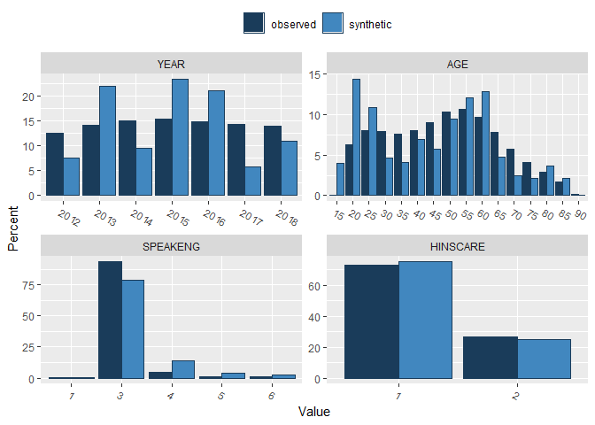

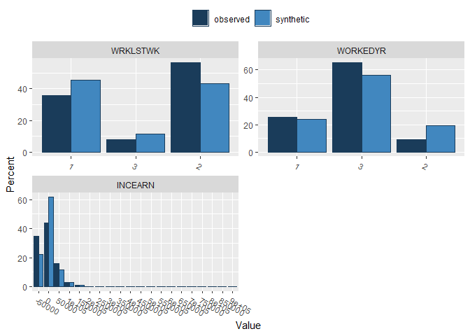

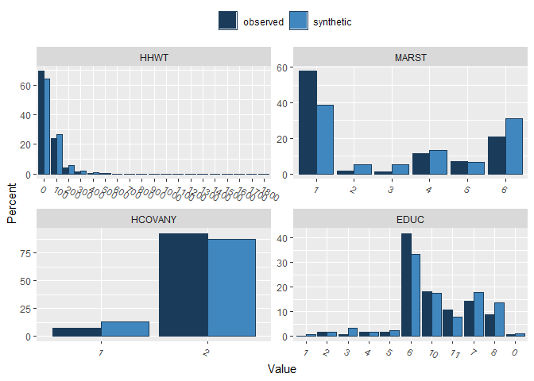

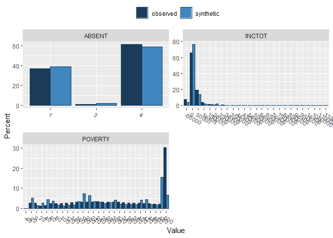

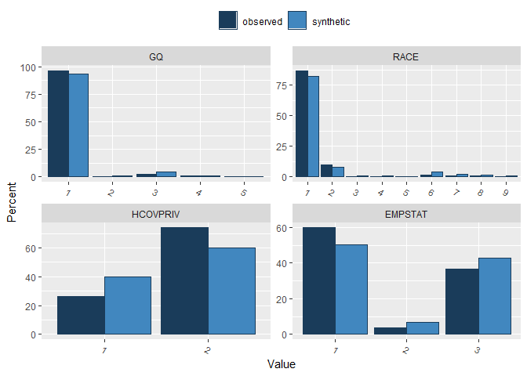

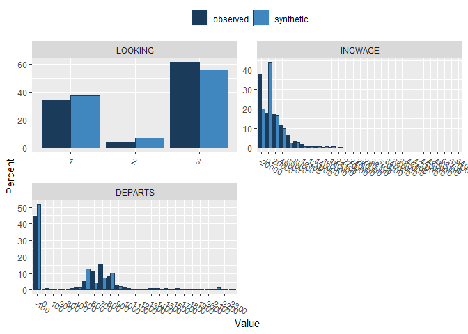

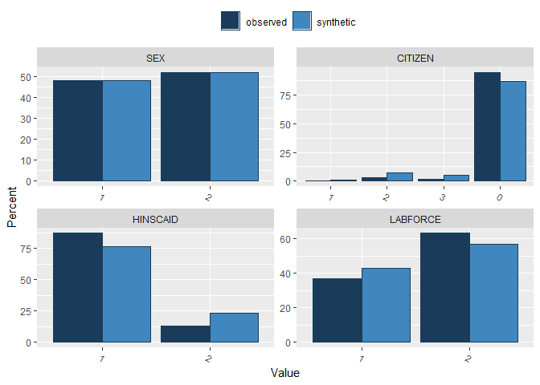

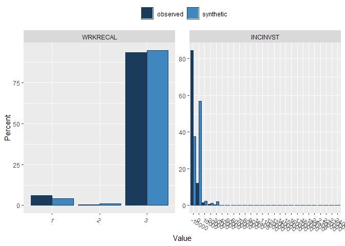

### Correlation Plots for Graphical Comparison of Pearson Correlation

Synthetic Datasets should represent the dependencies of the original datasets. The following correlation plots provide an ad-hoc overview on the Pearson correlations of the original and synthetic dataset. The left plot shows the original correlation whereas the right plot provides the correlation based on the synthetic dataset.

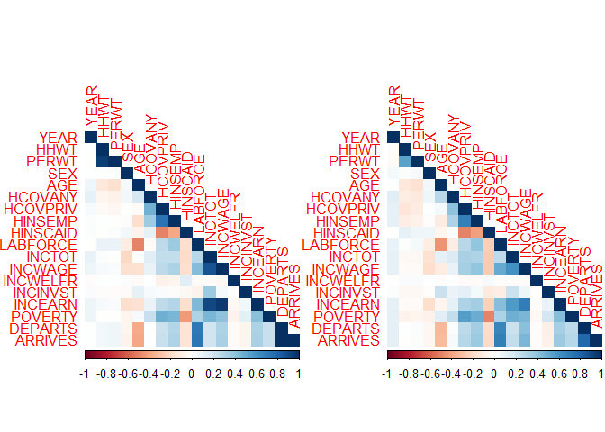

### Distributional Comparison of Synthesised Data (R-Package: synthpop) by (S_)pMSE

Propensity scores are calculated on a combined dataset (original and synthetic). A model (here: CART) tries to identify the synthetic units in the dataset. Since both datasets should be identically structured, the pMSE should equal zero. The S_pMSE (standardised pMSE) should not exceed 10 and for a good fit below 3 according to Raab (2021, https://unece.org/sites/default/files/2021-12/SDC2021_Day2_Raab_AD.pdf)

|  | pMSE | S_pMSE | df |
| --- | --- | --- | --- |
| YEAR | 0.0135632 | 37441.701 | 6 |
| AGE | 0.0116103 | 48076.115 | 4 |
| SPEAKENG | 0.0107432 | 44485.286 | 4 |
| HINSCARE | 0.0001238 | 2050.923 | 1 |
| WRKLSTWK | 0.0044304 | 36690.457 | 2 |
| WORKEDYR | 0.0055422 | 45898.084 | 2 |
| INCEARN | 0.0332500 | 137681.705 | 4 |

| pMSE | S_pMSE |
| --- | --- |
| 0.1371639 | 140.9911 |

|  | pMSE | S_pMSE | df |
| --- | --- | --- | --- |
| HHWT | 0.0031583 | 13077.92 | 4 |
| MARST | 0.0121554 | 40266.50 | 5 |
| HCOVANY | 0.0021357 | 35373.25 | 1 |
| EDUC | 0.0060960 | 10097.02 | 10 |
| ABSENT | 0.0003480 | 2882.38 | 2 |
| INCTOT | 0.0035312 | 14622.03 | 4 |
| POVERTY | 0.0043482 | 18005.02 | 4 |

| pMSE | S_pMSE |
| --- | --- |
| 0.0808016 | 57.79566 |

|  | pMSE | S_pMSE | df |
| --- | --- | --- | --- |
| GQ | 0.0018455 | 7641.756 | 4 |
| RACE | 0.0050582 | 10472.443 | 8 |
| HCOVPRIV | 0.0052671 | 87240.296 | 1 |
| EMPSTAT | 0.0029431 | 24373.495 | 2 |
| LOOKING | 0.0013935 | 11540.811 | 2 |
| INCWAGE | 0.0335343 | 138858.787 | 4 |
| DEPARTS | 0.0097650 | 53913.483 | 3 |

| pMSE | S_pMSE |
| --- | --- |
| 0.1917524 | 321.7915 |

|  | pMSE | S_pMSE | df |
| --- | --- | --- | --- |
| SEX | 0.0000001 | 9.521136e-01 | 1 |
| CITIZEN | 0.0046015 | 2.540531e+04 | 3 |
| HINSCAID | 0.0044901 | 7.437076e+04 | 1 |
| LABFORCE | 0.0009779 | 1.619639e+04 | 1 |
| WRKRECAL | 0.0007581 | 6.278456e+03 | 2 |
| INCINVST | 0.0553913 | 4.587289e+05 | 2 |

| pMSE | S_pMSE |
| --- | --- |
| 0.1884497 | 490.0153 |

### Two-way Tables Comparison of Synthesised Data (R-Package: synthpop) by (S_)pMSE

Two-way tables are evaluated based on the original and the synthetic dataset based on S_pMSE (see above). We also present the results for the mean absolute difference in densities (MabsDD) and the Bhattacharyya distance (dBhatt).

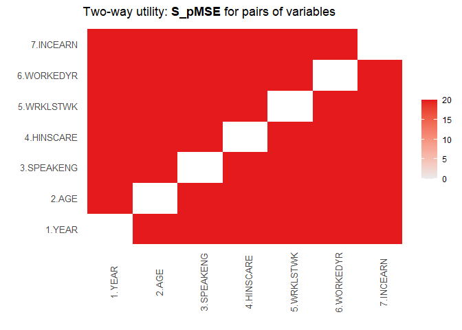

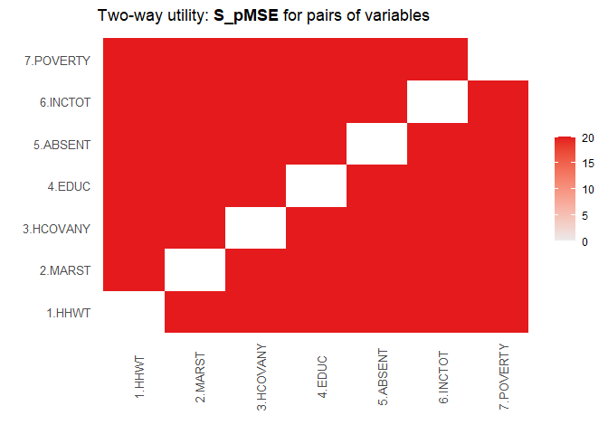

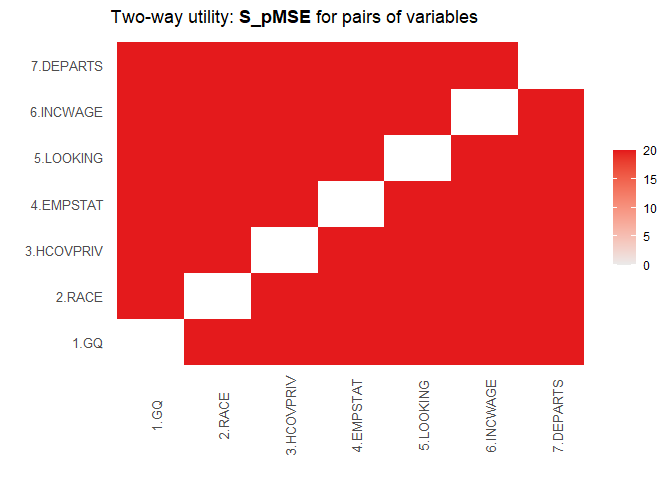

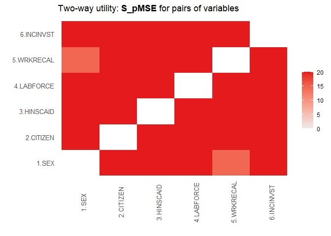

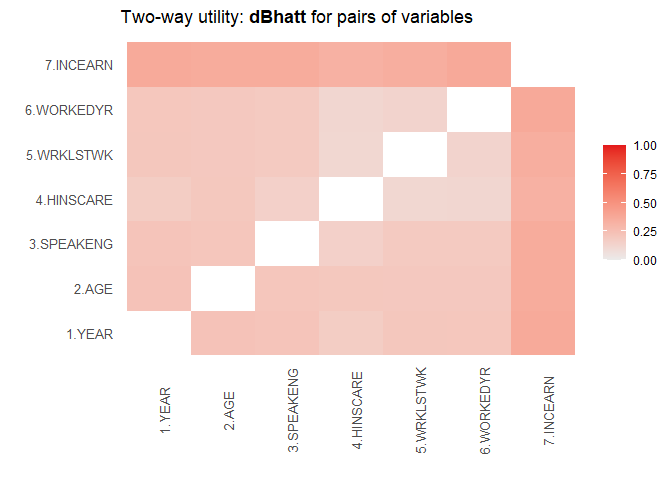

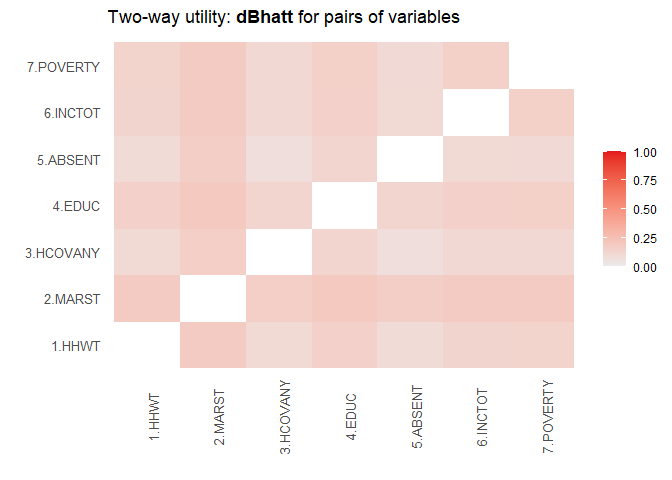

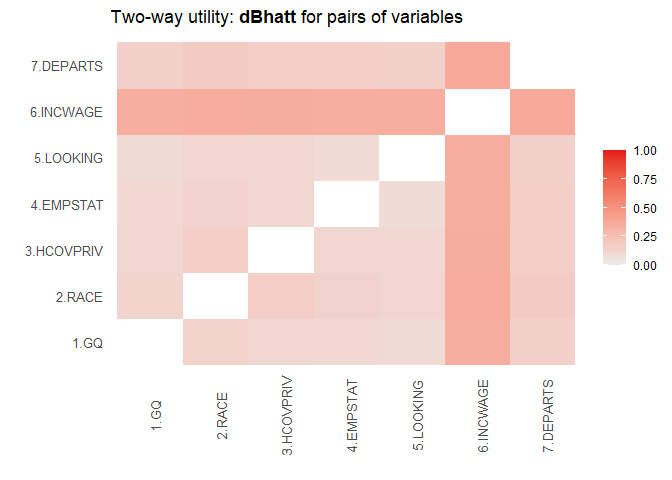

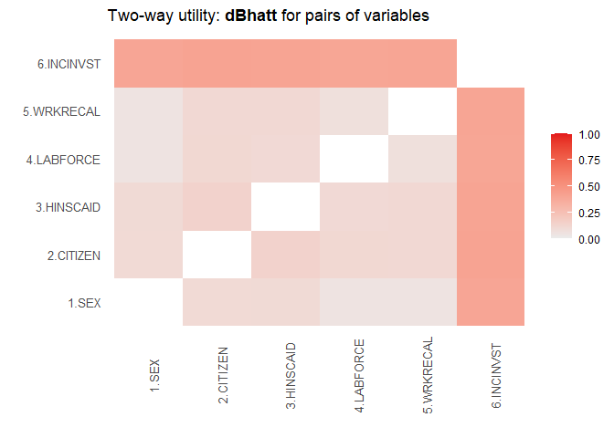

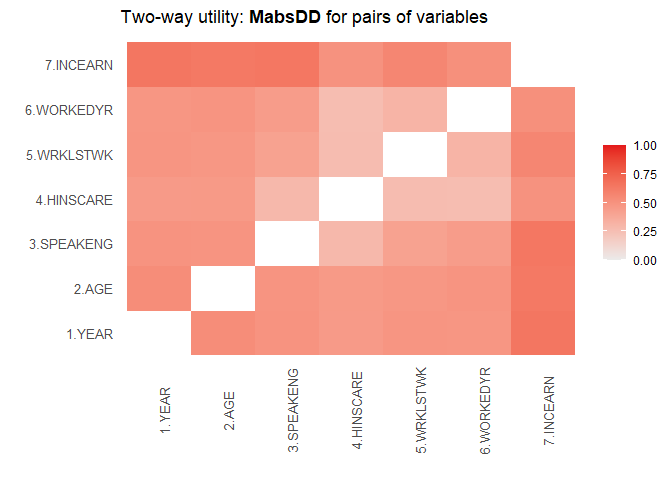

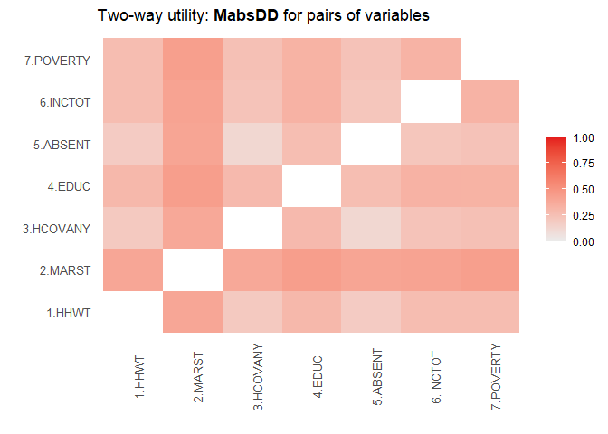

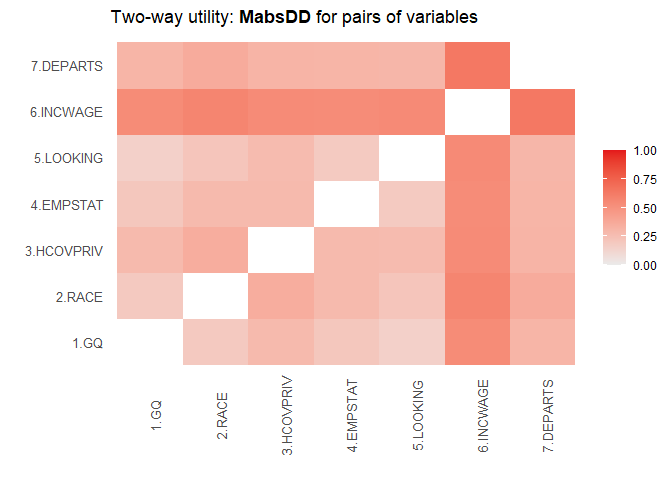

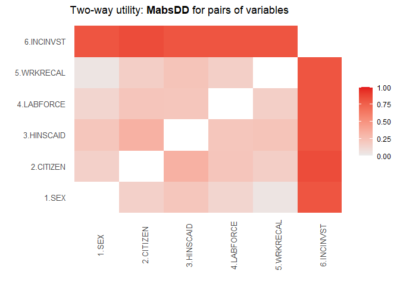

### Information Loss Measure Proposed by Andrzej Mlodak (R-Package: sdcMicro)

The value of this information loss criterion is between 0 (no information loss) and 1. It is calculated overall and for each variable.

```
## [1] 0.5616973
## attr(,"indiv_distances")
##       YEAR       HHWT         GQ      PERWT        SEX        AGE      MARST
## 0.85508418 0.95945851 0.09829975 0.95905994 0.49935230 0.91471230 0.69000996
##       RACE     HISPAN    CITIZEN   SPEAKENG    HCOVANY   HCOVPRIV    HINSEMP
## 0.27595704 0.11088185 0.17048380 0.25596575 0.18490612 0.45099937 0.50200492
##   HINSCAID   HINSCARE       EDUC    EMPSTAT   EMPSTATD   LABFORCE   WRKLSTWK
## 0.30127676 0.38379890 0.78324596 0.53886830 0.83006006 0.48095974 0.58594708
##     ABSENT    LOOKING   AVAILBLE   WRKRECAL   WORKEDYR     INCTOT    INCWAGE
## 0.49174122 0.52430687 0.26801945 0.11229703 0.55307327 0.99968486 0.99051450
##   INCWELFR   INCINVST    INCEARN    POVERTY    DEPARTS    ARRIVES
## 0.01535592 0.83495156 0.99219440 0.94552969 0.76413905 0.77456653
## attr(,"n")
## [1] 1035201
## attr(,"class")
## [1] "il_variables"
```